# Stability selection in high-dimensional regression

Enrico Moriggi, Matteo Suardi

2025-11-16

```r
library(glmnet)
library(stabs)
set.seed(123)
```

# 1 Introduction

In high-dimensional regression, particularly when the number of predictors largely exceeds the sample size ($p \gg n$), standard penalised methods like the Lasso provide sparse solutions but often suffer from severe instability. As noted by Meinshausen and Bühlmann (2010), small perturbations in the data (such as removing a few observations) can lead to arbitrarily different active sets, casting doubt on the scientific reliability of the selected variables.

Stability selection addresses this structural instability by combining resampling techniques with high-dimensional selection algorithms. Unlike standard cross-validation, which aims to minimise prediction error (often retaining too many noise variables), stability selection focuses on **variable recovery**, seeking predictors that persist across repeated random splits of the data. Crucially, this framework provides a theoretical upper bound on the expected number of False Positives (Per-Family Error Rate, PFER).

# 2 Methodological background

## 2.1 Lasso and regularisation path

We consider a linear regression model with response $Y \in \mathbb{R}^n$ and predictor matrix $X \in \mathbb{R}^{n \times p}$. The Lasso estimator is defined as the solution to the $\ell_1$-penalised optimisation problem:

$$\hat{\beta}(\lambda) = \arg\min_{\beta \in \mathbb{R}^p} \left\{
\frac{1}{2n}\,\|Y - X\beta\|_2^2 + \lambda \|\beta\|_1 \right\}$$

where $\lambda \ge 0$ is the tuning parameter governing the trade-off between the goodness of fit and the sparsity of the solution. The collection of estimates $\{ \hat{\beta}(\lambda) : \lambda \in \Lambda \}$ for a grid of penalty parameters $\Lambda$ constitutes the regularisation path. While effective for variable selection, the Lasso path can be unstable in high-dimensional settings ($p \gg n$), where small perturbations in the data may result in different active sets $\hat{S}(\lambda) = \{j : \hat{\beta}_j(\lambda) \neq 0\}$.

## 2.2 Stability selection and error control

To address the instability of single-run selection methods, stability selection aggregates selection results across repeated subsampling of the data. Modern implementations, such as the `stabs` package used in this analysis, typically employ **Complementary Pairs Stability Selection (CPSS)**.

Instead of drawing simple random subsamples, CPSS draws $B$ pairs of subsamples $\{(I_{2b-1}, I_{2b})\}_{b=1}^B$, where each pair forms a disjoint partition of the dataset $\{1, \dots, n\}$ of size $\lfloor n/2 \rfloor$. By using both halves of the data in each iteration, this approach ensures that every observation is used equally, significantly reducing the variance of the stability estimators compared to standard subsampling.

For a given $\lambda \in \Lambda$, the empirical *selection probability* of variable $j$ is defined as:

$$\hat{\pi}_j(\lambda) = \frac{1}{2B} \sum_{i=1}^{2B} \mathbf{1}\{ j \in
\hat{S}^{(i)}_{\lambda} \}$$

where $\hat{S}^{(i)}_{\lambda}$ denotes the set of variables selected by the Lasso on the $i$-th subsample. The set of curves $\{\hat{\pi}_j(\lambda)\}_{\lambda \in \Lambda}$ forms the *stability path*. It is important to emphasize that the empirical frequency $\hat{\pi}_j(\lambda)$ estimates the selection probability conditional on the subsample size $\lfloor n/2 \rfloor$, denoted as $P(j \in \hat{S}_{\lfloor n/2 \rfloor})$. Since variable selection is generally harder with fewer observations (lower statistical power), these probabilities are typically lower than those associated with the full sample size $n$. Consequently, stability selection is an inherently conservative procedure: a variable must be robust enough to be consistently detected even with only half of the available information.

## 2.3 Evaluation and error bound (PFER)

Variables are considered “stable” if their selection probability exceeds a pre-defined threshold $\pi$ (typically $\pi \in [0.6, 0.9]$). The set of stable predictors is determined by the maximum selection probability over the path:

$$\hat{S}_{stab} = \{ j : \max_{\lambda \in \Lambda} \hat{\pi}_j(\lambda)
\ge \pi_{thr} \}$$

A fundamental advantage of stability selection is the ability to control the **Per-Family Error Rate (PFER)**, defined as the expected number of false positives $E(V)$. Meinshausen and Bühlmann (2010) derived a theoretical upper bound which relates the error rate to the stability threshold $\pi$ and the average number of selected variables $q$:

$$E(V) \le \frac{q^2}{(2\pi - 1)p}$$

This bound assumes that the selection procedure is better than random guessing and holds under mild conditions (exchangeability). It allows us to explicitly control the amount of noise entering the model: by fixing an acceptable upper bound for $E(V)$ and choosing $q$ (e.g., by restricting the regularization path to the first $q$ variables), we can derive the necessary threshold $\pi$ to guarantee high-confidence selection.

# 3 Simulation study: from instability to error control

By contrasting these two designs, we disentangle the impact of feature correlation from the baseline performance of the algorithm, establishing a robust ground before applying the methodology to real-world data.

## 3.1 Design A: stability selection with correlated predictors

In this first example, we study a linear regression setting where predictors are organised into correlated blocks. This design mimics realistic high-dimensional applications (e.g., omics or imaging), in which groups of variables tend to be co-expressed. We demonstrate that, while a standard Lasso fit is sensitive to multicollinearity, stability selection can better distinguish robust predictors, provided we look at their behaviour across the entire regularisation path.

### 3.1.1 Data generation

We simulate a linear regression model with $n = 150$ observations and $p = 300$ predictors. Predictors are organised into three blocks: a strongly correlated block (1–100, $\rho=0.7$), a moderately correlated block (101–200, $\rho=0.3$), and an independent block (201-300, $\rho=0$). The 6 active variables are all located in the first (high correlation) block. This represents a “worst-case scenario” for variable selection.

Sample size and number of predictors:

```r
n <- 150
p <- 300
```

Indexes of truly active variables (all in the first block):

```r
S_true <- c(1, 2, 3, 10, 20, 30)
s <- length(S_true)
```

Regression coefficients (non-zero only on `S_true`):

```r
beta <- rep(0, p)
beta[S_true] <- c(1.5, 1.2, 1.0, 0.8, 0.8, 0.6) # different effect sizes
```

Build a block-correlated covariance matrix for X:

```r
Sigma <- diag(p)
```

Block 1: strong correlation (variables 1–100):

```r
rho1 <- 0.7
Sigma[1:100, 1:100] <- rho1
diag(Sigma[1:100, 1:100]) <- 1
```

Block 2: moderate correlation (variables 101–200):

```r
rho2 <- 0.3
Sigma[101:200, 101:200] <- rho2
diag(Sigma[101:200, 101:200]) <- 1
```

Block 3 (201–300) remains independent (identity).

Small ridge term to improve numerical stability:

```r
Sigma <- Sigma + 1e-6 * diag(p)
```

Simulate $X \sim N(0, \Sigma)$:

```r
library(MASS)
X <- MASS::mvrnorm(n = n, mu = rep(0, p), Sigma = Sigma)
```

Choose noise variance to obtain SNR = 2:

```r
signal_var <- as.numeric(t(beta) %*% Sigma %*% beta)
SNR <- 2
sigma2 <- signal_var / SNR
```

Generate response: $Y = X \beta + \varepsilon$

```r
eps <- rnorm(n, mean = 0, sd = sqrt(sigma2))
y <- as.numeric(X %*% beta + eps)
```

Colours for plots (true signals red, others grey):

```r
col_vec <- rep("lightgrey", p)
col_vec[S_true] <- "red"
```

### 3.1.2 Lasso fit and regularisation path

Before introducing stability selection, we first analyse the behaviour of the lasso when applied once to the full dataset. This preliminary step provides a baseline for comparison: by examining the regularisation path and the set of predictors selected at the cross-validated value $\lambda_{1se}$, we can assess how the lasso reacts under strong multicollinearity. In the block–correlated design considered here, this analysis reveals that the lasso recovers part of the true signal but also selects several correlated substitutes, motivating the need for a more robust and stable selection approach.

Lasso fit on the full dataset:

```r
fit <- glmnet(X, y)
```

Lambda grid used by glmnet:

```r
Lambda <- fit$lambda

Lambda
```

```
##   [1] 4.66564969 4.45358872 4.25116623 4.05794417 3.87350434 3.69744759
##   [7] 3.52939289 3.36897654 3.21585136 3.06968595 2.93016398 2.79698351
##  [13] 2.66985629 2.54850720 2.43267362 2.32210485 2.21656160 2.11581545
##  [19] 2.01964837 1.92785224 1.84022838 1.75658716 1.67674756 1.60053680
##  [25] 1.52778993 1.45834952 1.39206528 1.32879377 1.26839804 1.21074739
##  [31] 1.15571705 1.10318793 1.05304634 1.00518376 0.95949660 0.91588600
##  [37] 0.87425757 0.83452121 0.79659094 0.76038465 0.72582399 0.69283417
##  [43] 0.66134379 0.63128469 0.60259183 0.57520310 0.54905923 0.52410364
##  [49] 0.50028232 0.47754372 0.45583862 0.43512005 0.41534317 0.39646519
##  [55] 0.37844523 0.36124431 0.34482520 0.32915236 0.31419188 0.29991137
##  [61] 0.28627994 0.27326807 0.26084762 0.24899169 0.23767463 0.22687196
##  [67] 0.21656028 0.20671728 0.19732166 0.18835308 0.17979215 0.17162031
##  [73] 0.16381991 0.15637404 0.14926660 0.14248220 0.13600616 0.12982447
##  [79] 0.12392375 0.11829123 0.11291471 0.10778256 0.10288368 0.09820745
##  [85] 0.09374377 0.08948297 0.08541583 0.08153355 0.07782773 0.07429034
##  [91] 0.07091373 0.06769059 0.06461395 0.06167714 0.05887382 0.05619792
##  [97] 0.05364363 0.05120545 0.04887808 0.04665650
```

Cross-validated choice of lambda:

```r
cvfit <- cv.glmnet(X, y)
lambda_1se <- cvfit$lambda.1se

lambda_1se
```

```
## [1] 1.268398
```

Variables selected by the lasso at $\lambda_{1se}$:

```r
S_hat_lasso <- which(coef(fit, s = lambda_1se)[-1] != 0)

S_hat_lasso
```

```
##  [1]  1  2  9 10 20 27 30 34 48 60 74 86 93 97
```

True positives and missed signals:

```r
intersect(S_hat_lasso, S_true) # correctly recovered signals
```

```
## [1]  1  2 10 20 30
```

```r
setdiff(S_true, S_hat_lasso) # true signals missed by the lasso
```

```
## [1] 3
```

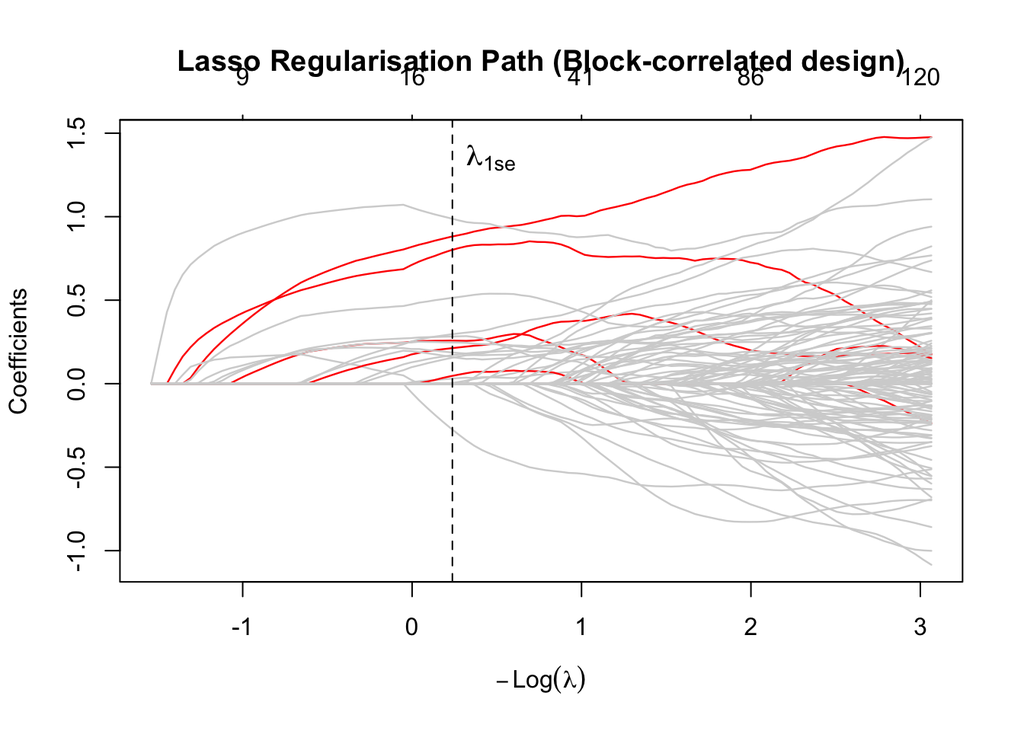

```r
plot(fit, xvar = "lambda", col = col_vec, lwd = 1.2,
     main = "Lasso Regularisation Path (Block-correlated design)")

abline(v = log(lambda_1se), lty = 2)

text(x = log(lambda_1se), y = max(coef(fit)[-1,]) * 0.9,
     labels = expression(lambda["1se"]), pos = 4, cex = 1.2, font = 2)
```

The plot displays the lasso regularisation path for the block–correlated design. The truly active variables (highlighted in red) belong to the first block with strong correlation ($\rho = 0.7$). As $\lambda$ decreases, several grey curves from the same block enter the model with similar shapes, indicating that correlated predictors act as substitutes.

At $\lambda_{1se}$, the lasso selects 14 predictors: it correctly recovers 5 out of the 6 true signals, but it also includes 9 spurious variables, most of them coming from the highly correlated first block. This behaviour illustrates how, in the presence of multicollinearity, a single lasso fit may mix true signals with correlated noise variables, leading to an unstable and harder-to-interpret model.

### 3.1.3 Stability paths via Complementary Pairs (CPSS)

To address the instability observed in the single Lasso fit and to strictly control variance, we implement Complementary Pairs Stability Selection (CPSS) (Shah & Samworth, 2013) manually for this design. Instead of simple random subsampling, we repeatedly split the data into two disjoint halves ($I_{2b-1}, I_{2b}$) of size $n/2$. The Lasso is fitted on both halves using the same $\lambda$ grid.

```r
B <- 50 # 50 iterations = 100 fits (2 per iteration)
S_hat_cpss <- array(NA, dim = c(2 * B, p, length(Lambda)))

set.seed(123)

for (b in 1:B) {
  perm <- sample(1:n)
  ind1 <- perm[1:(n/2)] # first half
  ind2 <- perm[(n/2 + 1):n] # second half

  fit_1 <- glmnet(X[ind1, ], y[ind1], lambda = Lambda)
  fit_2 <- glmnet(X[ind2, ], y[ind2], lambda = Lambda)

  S_hat_cpss[2*b - 1, , ] <- as.matrix(coef(fit_1)[-1, ] != 0)
  S_hat_cpss[2*b,     , ] <- as.matrix(coef(fit_2)[-1, ] != 0)
}

pi_hat <- apply(S_hat_cpss, 2:3, mean)
```

In this manual implementation, we deliberately fixed the regularization sequence $\Lambda$ to be identical across the full dataset and all subsamples. While standard practice in exploratory stability selection (Meinshausen and Bühlmann, 2010), it is worth nothing that the effective penalization strength relative to the sample size changes when $n$ drops to $\lfloor n/2 \rfloor$. This fixed-grid approach allows for a direct visual comparison of coefficient paths, but it contributes to the conservative nature of the selection: at a fixed numerical $\lambda$, the subsampled Lasso (with higher variance and lower power) tends to select fewer variables than the full-model Lasso. In the subsequent sections (Design B and Real data), we transition to the `stabs` package, which abstracts this issue by focusing on the $q$-parameter (number of selected variables) rather than the raw $\lambda$ values.

### 3.1.4 Visualization of the stability path

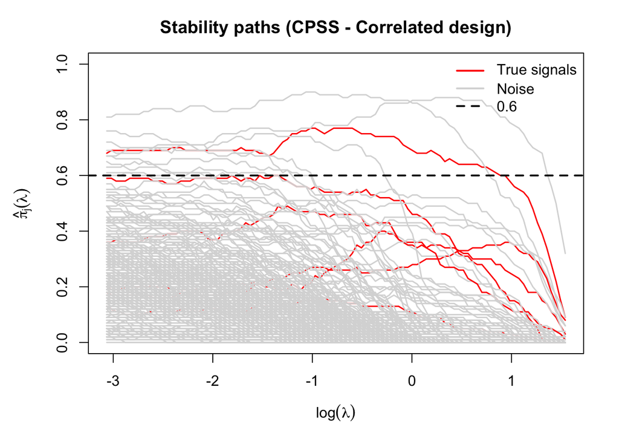

```r
tau <- 0.6
cols_all <- rep("grey85", p)
cols_all[S_true] <- "red"

par(mar = c(5, 5, 3, 2))
matplot(
  log(Lambda), t(pi_hat),
  type = "l", lty = 1, lwd = 1.5, col = cols_all,
  xlab = expression(log(lambda)),
  ylab = expression(hat(pi)[j](lambda)),
  main = "Stability paths (CPSS - Correlated design)",
  ylim = c(0, 1)
)
abline(h = tau, lty = 2, lwd = 2)
legend("topright", legend = c("True signals", "Noise", expression(tau=0.6)),
       col = c("red", "grey85", "black"), lty = c(1, 1, 2), lwd = 2, bty="n")
```

### 3.1.5 Stability-selected set (maximum probability criterion)

The stability paths reveal distinct behaviors. However, due to the strong block correlation ($\rho=0.7$), we anticipate a “signal dilution” effect: the Lasso splits its selection frequency among correlated surrogates, preventing some true signals from reaching high stability scores.

To define the stable set, we use the restricted maximization criterion ($q_{\lambda} \le 20$) to avoid the noise tail.

```r
q_hat <- apply(pi_hat, 2, sum)
valid_indices <- which(q_hat <= 20)

pi_max <- apply(pi_hat[, valid_indices], 1, max)

S_stab <- which(pi_max >= tau)

cat("Selected variables (CPSS):", S_stab, "\n")
```

```
## Selected variables (CPSS): 2 9 93 236
```

```r
cat("True signals recovered:", intersect(S_stab, S_true), "\n")
```

```
## True signals recovered: 2
```

```r
cat("False Positives:", setdiff(S_stab, S_true), "\n")
```

```
## False Positives: 9 93 236
```

```r
q_limit <- 20
PFER_A <- (q_limit^2) / ((2 * tau - 1) * p)

cat("Theoretical PFER Upper Bound (worst-case):", round(PFER_A, 2), "\n")
```

```
## Theoretical PFER Upper Bound (worst-case): 6.67
```

We successfully recovered only **1 out of 6** true signals (Variable 2). This low sensitivity is a direct consequence of the block-correlation structure. As the Lasso arbitrarily alternates between correlated surrogates across subsamples, the selection probability is “diluted” among the group, preventing other active variables from reaching the threshold $\tau = 0.6$.

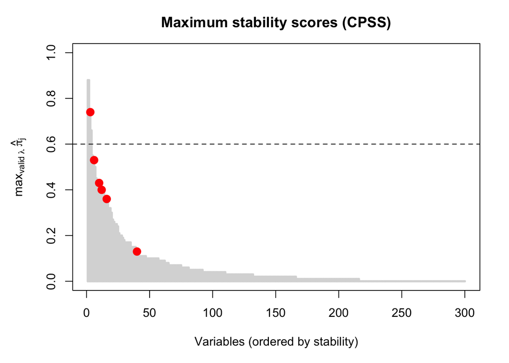

```r
ord_A <- order(pi_max, decreasing = TRUE)
pi_ordA <- pi_max[ord_A]

par(mar = c(5, 5, 3, 2))
plot(x = seq_along(pi_ordA), y = pi_ordA, type = "h", lwd = 3, col = "grey85",
     xlab = "Variables (ordered by stability)",
     ylab = expression(max[valid~lambda] ~ hat(pi)[j]),
     main = "Maximum stability scores (CPSS)", ylim = c(0, 1))

abline(h = tau, lty = 2)

is_signal_ord <- ord_A %in% S_true
points(x = which(is_signal_ord),
       y = pi_ordA[is_signal_ord],
       pch = 19,
       cex = 1.4,
       col = "red")
```

The bar plot vividly illustrates the challenge of strong multicollinearity ($\rho=0.7$). Due to signal dilution (vote-splitting), the Lasso arbitrarily alternates between correlated surrogates across subsamples. Consequently, the selection probability is split among the true predictors (red dots), preventing them from reaching the strict stability threshold $\tau=0.6$. While this results in low sensitivity, the method’s value lies in its comparison with the standard Lasso. The single Lasso fit at $\lambda_{1se}$ selected 14 variables (9 false positives). Stability selection, even in this “hostile” scenario, filtered out the vast majority of that noise, highlighting the inherent ambiguity of the data rather than providing a misleadingly confident model.

### 3.1.6 Discussion of Design A results

The results of Design A illustrate the inherent trade-off when applying standard stability selection to highly correlated data (a violation of the *Exchangeability condition*, Meinshausen 2010).

## 3.2 Design B: complementary pairs stability selection and error control

The second simulated design focuses on Complementary Pairs Stability Selection (CPSS) and on the theoretical error bound derived by Meinshausen and Bühlmann (2010). To match as closely as possible the assumptions behind the theory, we consider a high-dimensional linear model with independent predictors: only the first $s = 20$ variables carry signal, while the remaining $p - s$ predictors are pure noise. In this setting we are less interested in the instability induced by correlation, and more in quantifying how conservative the theoretical Per-Family Error Rate (PFER) bound is when applied to CPSS in practice.

### 3.2.1 Data generation with independent predictors

We generate a high-dimensional linear regression model with $n_2 = 150$ observations and $p_2 = 800$ predictors.  
Only the first $s_2 = 20$ variables are truly active with coefficient equal to 1, while the remaining predictors are pure noise.  
The predictors are independent, and the noise variance is chosen so that the signal-to-noise ratio (SNR) equals 1, which makes the selection problem non-trivial but still interpretable.

```r
set.seed(777)

n2 <- 150
p2 <- 800
s2 <- 20 # number of true signals

beta2 <- c(rep(1, s2), rep(0, p2 - s2))
S_true2 <- which(beta2 != 0) # indices of true signals
```

Independent predictors ($\Sigma = I$):

```r
Sigma2 <- diag(p2)
```

Noise variance for SNR = 1:

```r
signal_var2 <- as.numeric(t(beta2) %*% Sigma2 %*% beta2)
SNR2 <- 1
sigma2_2 <- signal_var2 / SNR2
```

Simulate $X_2$ and $y_2$:

```r
X2 <- matrix(rnorm(n2 * p2), nrow = n2, ncol = p2)
eps2 <- rnorm(n2, mean = 0, sd = sqrt(sigma2_2))
y2 <- as.numeric(X2 %*% beta2 + eps2)

col_vec2 <- rep("lightgrey", p2)
col_vec2[S_true2] <- "red"
```

### 3.2.2 CPSS algorithm with `stabsel`

We apply complementary pairs stability selection using the `stabsel` function from the **stabs** package, taking the lasso as base selection procedure $\hat{S}_n$.  
The tuning parameters are set to $q = 40$ (expected number of selected variables on a half-sample) and cutoff $\tau = 0.6$.

```r
q2 <- 40 # expected number of selected variables per half-sample
tau2 <- 0.6

fit_stab2 <- stabsel(
  x = X2,
  y = y2,
  fitfun = glmnet.lasso,
  q = q2,
  cutoff = tau2,
  assumption = "none"
  )

fit_stab2
```

[output not shown]

[output cut: 58 more lines]

```
## 0.12 0.12 0.12 0.12 0.13 0.13 0.13 0.14 0.14 0.14 0.14 0.14 0.15 0.15 0.15 0.15
##  657   17  160  358  389  437  558  704   18  414  602  659  679  217  234  442
## 0.15 0.16 0.16 0.16 0.16 0.16 0.16 0.16 0.17 0.17 0.17 0.17 0.17 0.18 0.18 0.18
##  475  777  727  116  190  522  526  763    5   68  374  142  239  484  572  593
## 0.18 0.18 0.19 0.20 0.20 0.20 0.20 0.20 0.21 0.21 0.21 0.22 0.22 0.22 0.22 0.22
##  799  220  750  250  515  644  728   20  760  771  157  154  194  124  191  255
## 0.22 0.23 0.23 0.24 0.24 0.24 0.24 0.25 0.25 0.25 0.27 0.29 0.29 0.31 0.31 0.32
##  173   10  394   16  328  391  221  703  590    3    8   15    1    4    7   11
## 0.34 0.35 0.35 0.39 0.39 0.39 0.41 0.42 0.45 0.47 0.49 0.51 0.60 0.66 0.79 0.88
##
## ---
## Cutoff: 0.6; q: 40; PFER (*):  10
##    (*) or expected number of low selection probability variables
## PFER (specified upper bound):  10
## PFER corresponds to signif. level 0.0125 (without multiplicity adjustment)
```

The `stabsel` output reports four CPSS-selected variables:
$$\hat{S}_{\mathrm{stab}} = \{1,\,4,\,7,\,11\},$$
with the following estimated selection probabilities:

$$\hat{\pi}_1 = 0.60,\quad
\hat{\pi}_4 = 0.66,\quad
\hat{\pi}_7 = 0.79,\quad
\hat{\pi}_{11} = 0.88.$$

Since in Design B the true active set is
$$S_{\text{true}} = \{1,2,\ldots,20\},$$
all four selected variables are genuine signals. The empirical performance is therefore:
$$TP_{\mathrm{emp}} = 4, \qquad FP_{\mathrm{emp}} = 0.$$

### 3.2.3 Maximum estimated selection probability for each variable

In this section we examine the behaviour of CPSS by analysing the estimated selection probability $\hat{\pi}_j$ for each predictor.  
Instead of tracking full stability paths across $\lambda$, CPSS aggregates information from complementary half–samples and assigns to each variable a single stability score summarising how often it is selected across all resampled fits.  
Plotting these maximum selection probabilities provides an immediate visual separation between truly active predictors and noise variables, and allows us to assess how conservative CPSS is under the chosen tuning parameters $(q,\tau)$. This diagnostic step is crucial for understanding the global stability pattern of the model and for verifying whether CPSS successfully isolates the informative variables while suppressing spurious selections.

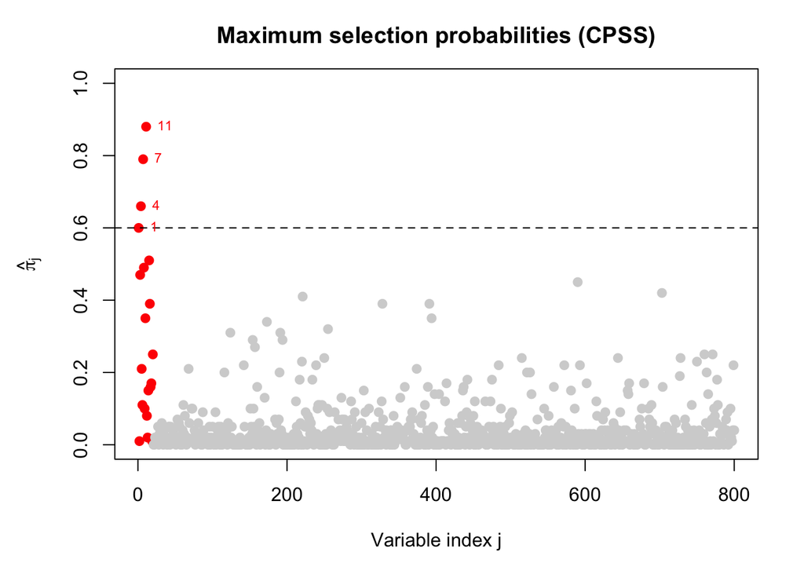

```r
pi_hat_max <- fit_stab2$max

col_vec2 <- rep("lightgrey", p2) # noise
col_vec2[S_true2] <- "red" # true signals

par(mar = c(5, 5, 3, 2))

plot(
  x = 1:p2,
  y = pi_hat_max,
  col = col_vec2,
  pch = 19,
  xlab = "Variable index j",
  ylab = expression(hat(pi)[j]),
  main = "Maximum selection probabilities (CPSS)",
  ylim = c(0, 1)
  )

abline(h = tau2, lty = 2)

true_above <- S_true2[ pi_hat_max[S_true2] >= tau2 ]

text(
  x = true_above,
  y = pi_hat_max[true_above],
  labels = true_above,
  pos = 4,
  cex = 0.7,
  col = "red"
  )
```

The figure above displays the $\hat{\pi}_j$. Each point corresponds to a variable: truly active predictors (indices $1$–$20$) are highlighted in red, whereas noise variables are shown in grey. The horizontal dashed line marks the stability cutoff $\tau = 0.6$.

In contrast, the vast majority of noise predictors have very low selection probabilities, concentrated in the range of $0$–$0.2$, with only a small fraction reaching values around $0.2$–$0.4$ and none approaching the stability cutoff. As a result, no pure-noise variable crosses the threshold. Overall, the figure illustrates how CPSS strongly suppresses false positives and prioritises the most stable true signals, at the cost of discarding moderately stable active predictors when a relatively stringent cutoff is used.

### 3.2.4 Empirical false positives vs Meinshausen & Bühlman bound

Stability-selected set from CPSS:

```r
S_stab2 <- fit_stab2$selected
S_stab2
```

```
##  1  4  7 11
##  1  4  7 11
```

True and noise indices:

```r
N2 <- setdiff(1:p2, S_true2)
```

Empirical number of false positives and true positives:

```r
FP_emp <- length(intersect(S_stab2, N2))
TP_emp <- length(intersect(S_stab2, S_true2))

FP_emp
```

```
## [1] 0
```

```r
TP_emp
```

```
## [1] 4
```

Theoretical upper bound on the expected number of false positives:

```r
bound_FP <- (1 / (2 * tau2 - 1)) * (q2^2 / p2)
bound_FP
```

```
## [1] 10
```

In our CPSS experiment we consider $p_2 = 800$ predictors, with tuning parameters $q = 40$ and $\tau = 0.6$.
The theoretical upper bound on the expected number of false positives is therefore
$$\frac{1}{2 \cdot 0.6 - 1} \cdot \frac{40^2}{800}
=
\frac{1}{0.2} \cdot \frac{1600}{800}
= 5 \cdot 2
= 10.$$

Consequently, the empirical numbers of true and false positives are
$$TP_{\mathrm{emp}} = 4,
\qquad
FP_{\mathrm{emp}} = 0.$$

Thus, in this realisation CPSS selects four true signals and no noise variables.  
The empirical number of false positives equals zero, which is far below the theoretical upper bound of $10$.  
This confirms the conservative nature of the Meinshausen–Bühlmann error bound and shows that, under these tuning parameters, CPSS achieves perfect false-positive control while still recovering the informative predictors.

### 3.2.5 Discussion of Design B results

# 4 Real-data application: stability selection on kidney transplant gene expression

In the final part of this report we apply lasso regression and stability selection to a genuine high-dimensional biomedical dataset: the `Einecke2010Kidney` gene expression data from kidney transplant recipients. The aim is to investigate whether gene expression profiles can help discriminate between biopsies with and without rejection, and to assess how stability selection behaves in a real, noisy omics scenario where the true set of relevant predictors is unknown.

## 4.1 Data description and pre-processing

The dataset contains 250 patients (rows) and 10,001 variables (columns): a binary outcome `Reject_Status` indicating whether the graft was rejected (1) or not (0), and the expression levels of 10000 genes, selected among the 25% most variable genes in the original study by Einecke et al. (2010).

```r
load("Einecke2010Kidney.rda")

str(Einecke2010Kidney)
```

```
## 'data.frame':    250 obs. of  10001 variables:
##  $ Reject_Status              : num  0 0 0 0 0 0 1 0 1 0 ...
##  $ X211352_s_at               : num  2.369 -1.488 0.556 0.127 -0.38 ...
##  $ X239275_at                 : num  1.055 -0.606 0.838 1.481 0.397 ...
##  $ X1554536_at                : num  1.2491 -2.0427 -0.7287 0.1914 -0.0522 ...
##  $ X1558452_at                : num  0.842 0.947 0.354 -1.156 1.273 ...
##  $ X1554249_a_at              : num  0.991 -0.967 1.544 0.601 1.417 ...
##  $ X234382_x_at               : num  0.462 1.317 -0.472 -0.296 1.293 ...
##  $ X1557126_a_at              : num  -0.637 0.651 -0.343 1.997 0.68 ...
##  $ X1554865_at                : num  1.45 -3.063 -0.837 1.579 -0.361 ...
##  $ X224489_at                 : num  -0.0863 -0.8983 -1.3072 1.3568 2.3829 ...
##  $ X237956_s_at               : num  -0.575 -0.941 -1.74 -0.401 -0.985 ...
##  $ X206300_s_at               : num  -0.783 -0.839 -0.477 -0.969 0.903 ...
##  $ X243856_at                 : num  -0.4618 -1.4183 -0.0251 -0.4214 0.6196 ...
##  $ X244331_at                 : num  1.051 0.181 1.574 0.471 -1.156 ...
```

[output cut: 86 more lines]

```r
dim(Einecke2010Kidney)
```

```
## [1]   250 10001
```

```r
table(Einecke2010Kidney$Reject_Status)
```

```
##
##   0   1
## 183  67
```

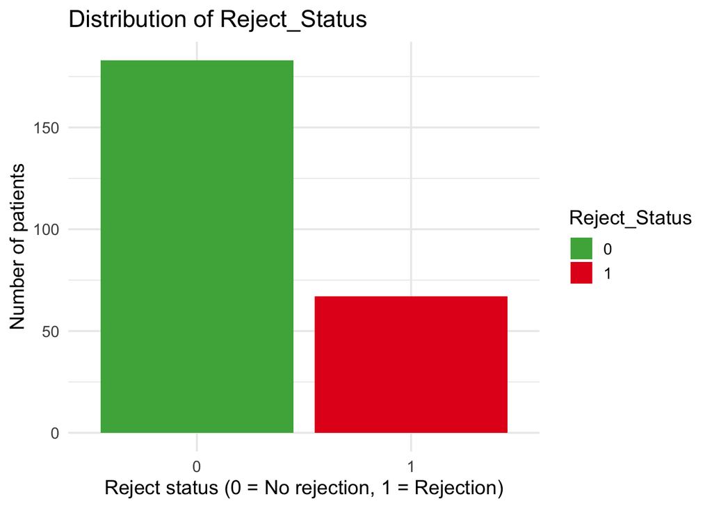

```r
library(ggplot2)
df_counts <- as.data.frame(table(Einecke2010Kidney$Reject_Status))
colnames(df_counts) <- c("Reject_Status", "Count")

ggplot(df_counts, aes(x = Reject_Status, y = Count, fill = Reject_Status)) +
  geom_bar(stat = "identity") +
  scale_fill_manual(values = c("#4DAF4A", "#E41A1C")) +
  labs(
    title = "Distribution of Reject_Status",
    x = "Reject status (0 = No rejection, 1 = Rejection)",
    y = "Number of patients"
  ) +
  theme_minimal(base_size = 14)
```

We treat `Reject_Status` as the binary outcome and all 10000 gene expression variables as predictors. The response variable is imbalanced (183 non-rejection vs 67 rejection), which increases model instability in half-sampling procedures, especially for logistic lasso.

```r
y <- Einecke2010Kidney$Reject_Status # outcome (0/1)

X_raw <- Einecke2010Kidney[, -1] # predictors
dim(X_raw)
```

```
## [1]   250 10000
```

### 4.1.1 Missing values and near-zero variance genes

First, we check for missing values and near-zero variance predictors. We remove genes that are practically constant to avoid numerical issues in Lasso.

```r
sum(is.na(y))
```

```
## [1] 0
```

```r
sum(is.na(X_raw))
```

```
## [1] 0
```

```r
# Remove near-zero variance predictors
library(caret)
nzv_idx <- nearZeroVar(X_raw)

if(length(nzv_idx) > 0) {
  X_nzv <- X_raw[, -nzv_idx]
  } else {
    X_nzv <- X_raw
    }

dim(X_nzv)
```

```
## [1]   250 10000
```

No missing values are present in either the outcome variable or in the gene expression matrix. Moreover, the diagnostic did not identify any gene with near-zero variance. This confirms that all 10000 gene expression features exhibit sufficient variability across the 250 patients and can therefore be retained for downstream modelling.

From a biological standpoint, this behaviour is consistent with standard microarray preprocessing pipelines, in which low-intensity or low-variance probes are typically filtered out during the initial quality-control stage. As a consequence, the dataset appears clean, well-behaved, and directly suitable for high-dimensional regression and stability selection, without requiring additional feature removal or imputation at this stage.

### 4.1.2 Standardization and data leakage prevention

Standardization (centering variables to mean zero and scaling to unit variance) is theoretically required for Lasso regression because the $\ell_1$ penalty term depends on the magnitude of the coefficients. If variables are not on the same scale, those with larger variances would be penalized disproportionately. A standard pre-processing pipeline would typically involve the following step:

```r
# THEORETICAL IMPLEMENTATION (not executed to avoid data leakage)

# In a standard setting, we would center and scale the full matrix X:
#library(caret)
#pp <- preProcess(X_raw, method = c("center", "scale"))
#X_scaled_global <- predict(pp, X_raw)

# However, applying this globally BEFORE subsampling constitutes data leakage
```

We deliberately do not apply this global transformation here. Using the global mean and standard deviation to scale observations that will later become “out-of-bag” samples in the stability selection loop constitutes data leakage. It introduces a dependency between the training and validation sets within the resampling procedure, potentially leading to optimistic bias.

Also, in this application we deliberately avoid further unsupervised transformations such as Box-Cox skewness correction, correlation-based filtering, or PCA feature extraction. First, the microarray expression values have already undergone a standard normalisation pipeline (including background correction and log-transformation), so their marginal distributions are reasonably well behaved for penalised regression. Second, our primary objective is gene-level variable selection and biological interpretability, rather than constructing abstract latent components. Introducing PCA or other feature-extraction steps would compress information into linear combinations of genes, making it harder to trace back which specific transcripts drive the prediction of rejection. Finally, redundancy and correlation among genes are handled downstream by the $\ell_1$ penalty and by stability selection, which are explicitly designed to operate in high-dimensional, highly correlated settings without requiring an additional, aggressive pre-filtering of the predictors.

Therefore, for the subsequent analysis, we define `X_mod` simply as the cleaned raw data:

```r
X_mod <- as.matrix(X_nzv)
y_mod <- y
```

### 4.1.3 Lasso logistic regression baseline

As a baseline, we fit a lasso-penalised logistic regression to predict rejection status from all preprocessed genes. We use 10-fold cross-validation to choose the regularisation parameter $\lambda$.

```r
set.seed(123)

cvfit_real <- cv.glmnet(
  X_mod, y_mod,
  family = "binomial",
  alpha = 1, # lasso
  standardize = TRUE,
  nlambda = 300
  )

lambda_min_real <- cvfit_real$lambda.min
lambda_1se_real <- cvfit_real$lambda.1se

lambda_min_real
```

```
## [1] 0.02837507
```

```r
lambda_1se_real
```

```
## [1] 0.1206978
```

For this dataset, cross-validation yields
$$\lambda_{\min} = 0.0284, \qquad
\lambda_{\mathrm{1se}} = 0.1207.$$

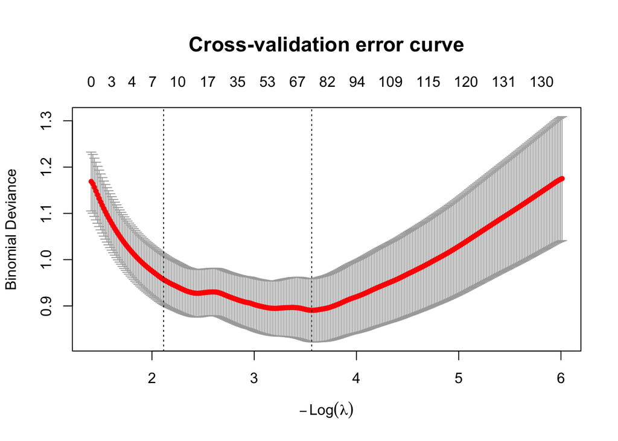

```r
op <- par(mar = c(5, 4, 6, 2) + 0.1)

plot(cvfit_real, main = "")

mtext(
  "Cross-validation error curve",
  side = 3,
  line = 3,
  cex = 1.4,
  font = 2
)
```

```r
par(op)
```

The value $\lambda_{\min}$ corresponds to a less penalised and therefore more complex model, whereas $\lambda_{\mathrm{1se}}$ enforces stronger shrinkage and produces a substantially sparser set of selected genes. In high-dimensional applications such as microarray analysis, the $1se$ rule is often preferred as a baseline because it improves interpretability and reduces the risk of selecting genes that are merely correlated surrogates rather than true biological signals. However, both values of $\lambda$ will serve as useful reference points when comparing the baseline lasso to the subsampling-based stability selection procedure applied in the next section.

```r
fit_real <- glmnet(
  X_mod, y_mod,
  family = "binomial",
  alpha = 1,
  lambda = cvfit_real$lambda,
  standardize = TRUE
  )

# Genes selected at lambda_1se
S_hat_lasso_real <- which(coef(fit_real, s = lambda_1se_real)[-1] != 0)
length(S_hat_lasso_real)
```

```
## [1] 8
```

```r
# Gene names of the baseline lasso signature
genes_lasso <- colnames(X_mod)[S_hat_lasso_real]
genes_lasso
```

```
## [1] "X226474_at"   "X205758_at"   "X229367_s_at" "X229437_at"   "X244598_at"
## [6] "X238531_x_at" "X220351_at"   "X206914_at"
```

From a practical viewpoint, such a sparse solution is appealing: it yields a concise “gene signature” that is easy to interpret and potentially testable in follow-up biological studies. At the same time, the absence of ground truth in a real microarray dataset means that we cannot directly quantify false positives or false negatives. The eight genes selected by the baseline lasso at $\lambda_{\mathrm{1se}}$ should therefore be regarded as a first, data-driven screening of potentially relevant transcripts. In the next section we will use subsampling-based stability selection to assess how robust these choices are with respect to perturbations of the sample, and to identify which genes remain consistently selected across resampled datasets.

A visual summary of the regularisation path is given by:

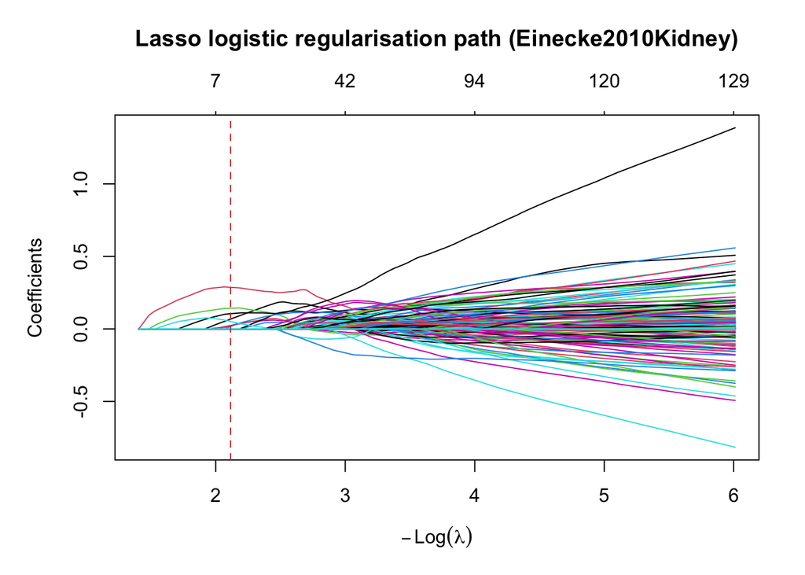

```r
par(mar = c(5, 5, 5, 2))

plot(
  fit_real,
  xvar = "lambda",
  main = ""
  )

title(
  main = "Lasso logistic regularisation path (Einecke2010Kidney)",
  line = 3
  )

abline(v = -log(lambda_1se_real), lty = 2, col = "red")
```

Each coloured curve represents the coefficient trajectory of one gene as the penalty parameter $\lambda$ decreases (i.e. as $-\log\lambda$ increases). For large values of $\lambda$, all coefficients are shrunk to zero, while progressively smaller penalisation allows more genes to enter the model.

Even in this high-dimensional setting, only a limited number of genes display substantial coefficient growth, while the vast majority remain close to zero across the entire path. The vertical dashed red line marks the value $\lambda_{\mathrm{1SE}}$, which corresponds to a sparse yet cross-validated choice of regularisation. At this point in the path, the lasso selects a small panel of genes (eight in our analysis), forming a preliminary molecular signature for graft rejection.

It is important to emphasise that, unlike the simulated experiments in earlier sections, the true set of biologically active genes is unknown in this real microarray dataset. Therefore we cannot assess false positives or false negatives directly. Moreover, a single lasso fit may be sensitive to minor perturbations of the data: correlated genes can enter or leave the model depending on which patients are included in the training sample. These considerations motivate the next stage of the analysis, where subsampling-based stability selection is used to quantify how consistently each gene is selected across many reweighted versions of the dataset, providing a more robust picture of variable importance.

### 4.1.4 Robust analysis: Complementary Pairs Stability Selection (CPSS)

```r
set.seed(123)

p_real <- ncol(X_mod)
q_real <- 80
tau_real <- 0.6

fit_stab_real <- stabsel(
  x = X_mod, y = y_mod,
  fitfun = glmnet.lasso,
  args.fitfun = list(
      family = "binomial",
      standardize = TRUE
  ),
  q = q_real,
  cutoff = tau_real,
  assumption = "none"
)
```

### 4.1.5 Results and PFER control

```r
S_stab <- fit_stab_real$selected
pi_max_real <- fit_stab_real$max

cat("CPSS strictly selected genes (tau=0.6):\n")
```

```
## CPSS strictly selected genes (tau=0.6):
```

```r
print(names(S_stab))
```

```
## [1] "X238531_x_at"
```

```r
PFER_val <- (q_real^2) / ((2 * tau_real - 1) * p_real)
cat("Theoretical PFER upper bound:", PFER_val, "\n")
```

```
## Theoretical PFER upper bound: 3.2
```

To assess the reliability of this selection, we compute the theoretical upper bound on the PFER, defined as the expected number of false positives $E(V)$. According to Meinshausen and Bühlmann, the bound is given by:

$$\mathbb{E}(V) \le \frac{q^2}{(2\tau - 1)p}$$

Substituting our parameters ($p=10000$, $q=80$, $\tau=0.6$):

$$\mathbb{E}(V) \le \frac{80^2}{(2 \cdot 0.6 - 1) \cdot 10000} =
\frac{6400}{0.2 \cdot 10000} = \frac{6400}{2000} = 3.2$$

This result implies that, even in a worst-case scenario where the signal is purely random noise, we would expect strictly fewer than $3.2$ false positives. Since our procedure selected only 1 variable (which is $< 3.2$), the selection is statistically robust and the probability that this gene is a false discovery is minimized.

### 4.1.6 Visualising the stability landscape (Manhattan plot)

To provide a global perspective on variable importance, we visualize the maximum stability scores $\hat{\pi}^{\max}_j$ for all $p=10000$ genes using a Manhattan-style plot.

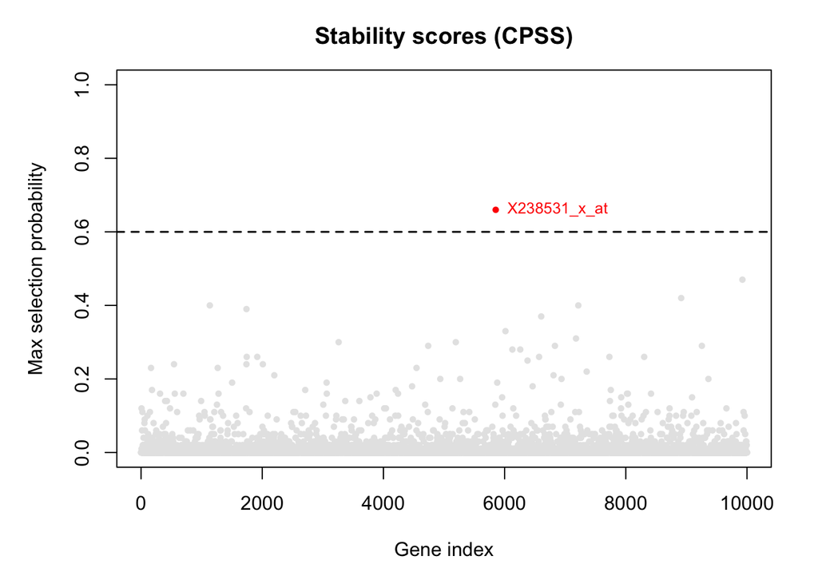

```r
par(mar = c(5, 5, 3, 2))
plot(1:p_real, pi_max_real,
     pch = 19, col = ifelse(pi_max_real >= tau_real, "red", "grey90"),
     cex = 0.6,
     xlab = "Gene index", ylab = "Max selection probability",
     main = "Stability scores (CPSS)", ylim = c(0, 1))

abline(h = tau_real, lty = 2, col = "black", lwd = 1.5)

sel_idx <- which(pi_max_real >= tau_real)
text(sel_idx, pi_max_real[sel_idx], labels = names(S_stab), pos = 4, cex = 0.8, col = "red")
```

### 4.1.7 Sensitivity analysis: relaxing the error control

Ideally, identifying a panel of multiple biomarkers would be preferable to a single gene. To rule out the possibility that our strict error control ($\tau=0.6$) was masking weaker but potentially biologically relevant signals, we performed a sensitivity analysis by relaxing the stability threshold. Specifically, we maintained the search depth constant ($q=80$) but lowered the stability cutoff to $\tau = 0.51$. This setting implicitly accepts a massive increase in the theoretical risk of false discoveries.

```r
stab_relaxed <- stabs::stabsel(
  x = X_mod,
  y = y_mod,
  fitfun = glmnet.lasso,
  args.fitfun = list(family = "binomial", standardize=TRUE),
  q = 80,
  cutoff = 0.51,
  assumption = "none",
  B = 100
)

cat("Selected variables with q=80 and cutoff=0.51:\n")
```

```
## Selected variables with q=80 and cutoff=0.51:
```

```r
print(names(stab_relaxed$selected))
```

```
## [1] "X238531_x_at"
```

```r
PFER_relaxed <- (80^2) / ((2 * 0.51 - 1) * ncol(X_mod))
cat("Implied PFER (very high risk):", round(PFER_relaxed, 1), "\n")
```

```
## Implied PFER (very high risk): 32
```

This experiment acts as a methodological “stress test.” By lowering the threshold to $\tau=0.51$, the theoretical Meinshausen-Bühlmann bound skyrockets to PFER = 32. In other words, we are theoretically willing to accept up to 32 false positives just to find new candidates. Ideally, such a permissive setting would flood the model with secondary signals. Instead, we observed a striking result: only the single dominant gene (`X238531_x_at`) was recovered. This leads to three crucial conclusions:

1. **Enormous signal gap**: the distance between the top signal and the rest of the transcriptome is vast. There are no “hidden” variables just below the surface waiting to be found; there is one strong driver and a sea of noise.
2. **Invariance**: the selection of `X238531_x_at` is invariant to parameter tuning. Whether we are strict (PFER=3.2) or reckless (PFER=32), it is the only variable that consistently emerges.
3. **Statistical justification**: pursuing additional candidates (like the runner-ups seen in the bar plot in the next subsection) would be statistically unjustified on this dataset alone, as even extreme relaxation fails to distinguish them from random noise.

### 4.1.8 Exploratory analysis: the top-ranked candidates

While strict error control ($\tau=0.6$) isolates a single predictor, looking at the ranking of the most stable genes offers valuable biological insights for prioritization. The bar chart below visualizes the “stability gap” between the robust leader and the runners-up.

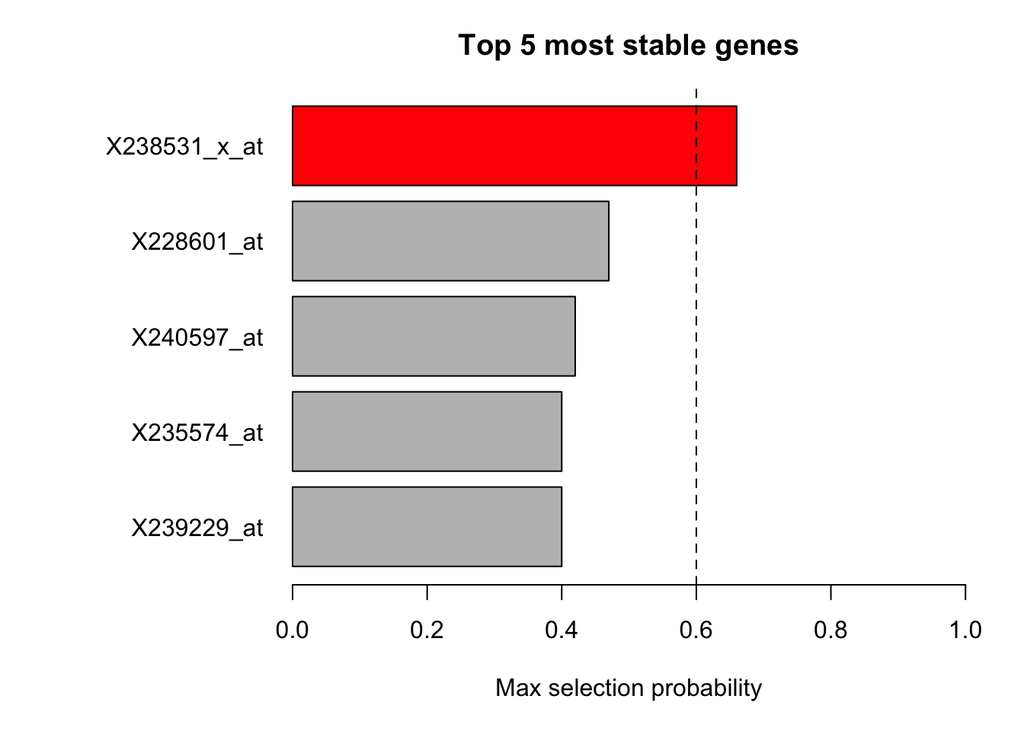

```r
top_idx <- order(pi_max_real, decreasing = TRUE)[1:5]
top_genes <- colnames(X_mod)[top_idx]
top_scores <- pi_max_real[top_idx]

par(mar = c(5, 10, 3, 2))
barplot(rev(top_scores), horiz = TRUE, names.arg = rev(top_genes), las = 1,
        col = ifelse(rev(top_scores) >= tau_real, "red", "grey"),
        xlab = "Max selection probability", main = "Top 5 most stable genes",
        xlim = c(0, 1))
abline(v = tau_real, lty = 2)
```

1. **High priority**: the red gene is statistically validated with controlled PFER.
2. **Low priority / ambiguous**: the grey genes might be biologically relevant (potential False Negatives due to the conservative nature of the method), but they are statistically indistinguishable from unstable noise selection. Investing resources in them carries a higher risk of failure compared to the stable target.

### 4.1.9 Discussion of real data results

In conclusion, Stability Selection successfully prioritized safety over model complexity. It demonstrated that in noisy omics scenarios, it is scientifically preferable to identify one robust, reproducible signal with controlled error guarantees than to pursue a larger panel of predictors contaminated by false discoveries.

# 5 General conclusions

In this report, we investigated **stability selection** as a rigorous statistical framework to address the structural instability of variable selection in high-dimensional regression ($p \gg n$). By shifting the focus from minimising prediction error (as in standard Cross-Validation) to maximizing **selection reliability**, we demonstrated how this method provides a principled solution to the “Curse of Dimensionality.”

**Final recommendation:** stability selection should not be viewed merely as a competitor to the Lasso, but as a necessary **quality assurance layer**. In high-stakes scientific domains (such as genomics or clinical diagnostics) where the cost of a False Positive is high, the explicit error control provided by the PFER bound makes Stability Selection the superior choice for reproducible feature selection.

# 6 Further improvements and perspectives

While our analysis successfully demonstrated the robustness of stability selection, several methodological and biological aspects remain open for further refinement. We outline four key directions for improving sensitivity, theoretical validity, and real-world interpretability, together with a critical assessment of the limitations inherent in our current design.

**1. Stratified stability selection for imbalanced outcomes**

In the kidney dataset (67 rejections vs 183 non-rejections), complementary half-sampling does not guarantee that class proportions are preserved. Some half-samples may contain very few rejection cases, artificially lowering the stability of clinically relevant genes.

*Improvement:* implement **stratified CPSS**, where half-samples are drawn separately within each class to maintain the original class ratio. Since this functionality is not natively supported in the `stabs` package, it would require a custom modification of the subsampling routine. Stratification would reduce variance in the logistic base learner and might enable moderately stable genes (e.g., `X229367_s_at`) to cross the stability threshold $\tau$.

**2. Cluster-based stability selection in high-correlation regimes**

Design A showed clear evidence of “signal dilution”: with strong correlations ($\rho = 0.7$), the Lasso alternates among highly correlated surrogates, distributing selection probability across them and violating the exchangeability assumption.

*Improvement:* pre-cluster predictors using gene co-expression or correlation networks, apply stability selection to cluster representatives, and propagate cluster-level stability back to individual genes. This enforces stability at the level of correlated gene modules—more consistent with biological pathways—and mitigates vote-splitting among surrogates.

**3. Refining the base procedure: Randomized Lasso and Elastic Net**

The standard Lasso relies on the *irrepresentable condition*, which is often violated in high-correlation settings. Even with stability selection, this limitation can reduce sensitivity.

*Improvement:*

- **Randomized Lasso** (Meinshausen & Bühlmann, 2010): introduces random penalisation weights, weakening the irrepresentable condition and reducing deterministic preference for specific correlated variables.
- **Elastic Net** (Zou & Hastie, 2005): incorporates an $\ell_2$ penalty that promotes the grouping effect, stabilising the selection of correlated predictors.

Both approaches would likely improve the sensitivity of stability selection in block-correlated designs like Design A.

**4. Towards biological validity: interpretation and external replication**

Selecting a statistically stable gene in a single microarray dataset is insufficient for biological discovery, particularly given the prevalence of platform-specific noise.

*Improvement:*

- **External validation:** the most reliable assessment is to test the stability-selected gene (`X238531_x_at`) on an independent kidney transplant cohort, ideally obtained from a different laboratory or microarray platform to exclude batch-driven artefacts.
- **Quality control:** before interpreting any biological conclusion, rigorous investigation of **batch effects**, platform variability, and preprocessing steps is essential to ensure that the signal is biological rather than technical.
- **Biological interpretation:** perform Gene Ontology enrichment, pathway analysis, and a literature review to establish whether the gene has known mechanistic links to graft rejection.

**5. Methodological caveats**

Two methodological limitations of our current implementation must be explicitly acknowledged:

- **Manual CPSS control in Design A**  
  In Design A, we used a fixed $\lambda$-grid for all subsamples and did not explicitly control the parameter $q$ (expected number of selected variables per half-sample). Therefore, the theoretical PFER bound does **not** formally apply in that simulation. Future work will adopt a $q$-constrained selection path or rely directly on the official `stabs` implementation to enforce theoretical guarantees.
- **Threshold selection**  
  The stability threshold $\tau = 0.6$ was chosen as a compromise to obtain a low expected PFER ($< 3.2$), but this choice warrants a sensitivity analysis. Lower $\tau$ increases recall but weakens error control; higher $\tau$ increases specificity at the risk of discarding moderately stable true signals. Examining model behaviour across a range of $\tau$ values would provide a more complete understanding of the trade-offs involved.